fossil

# Robust Poisson against outliers, dug back up.

Chen, Shi, Qian and Azen asked which model for relative risks holds up when a few outcomes are recorded wrong. Their SAS program was never released. We rebuilt the simulation from the paper and ran all 24 scenarios again. 863 of 864 printed table cells came back within Monte Carlo error.

See every resultSee Fig. 1

## Install robustrr

Python package

```
pip install "git+https://github.com/jeonglab-bcm/fossil#subdirectory=PMC4079617/package"
```

Python 3.10 or later; the only dependency is NumPy. Language: Python, by the default rule (the authors' code was SAS, which only proprietary software runs, and the method needs no R or Bioconductor package).

[README](https://github.com/jeonglab-bcm/fossil/blob/main/PMC4079617/package/README.md) [Tutorial](https://github.com/jeonglab-bcm/fossil/blob/main/PMC4079617/package/tutorial/TUTORIAL.md)

## Fig. 1

Relative bias (%) of the log RR by contamination rate, n = 1500. Panels A and B linear Z, C and D non-linear Z; A and C moderate, B and D strong association. Log-binomial blue and solid, robust Poisson red and dashed.

Agrees

Published

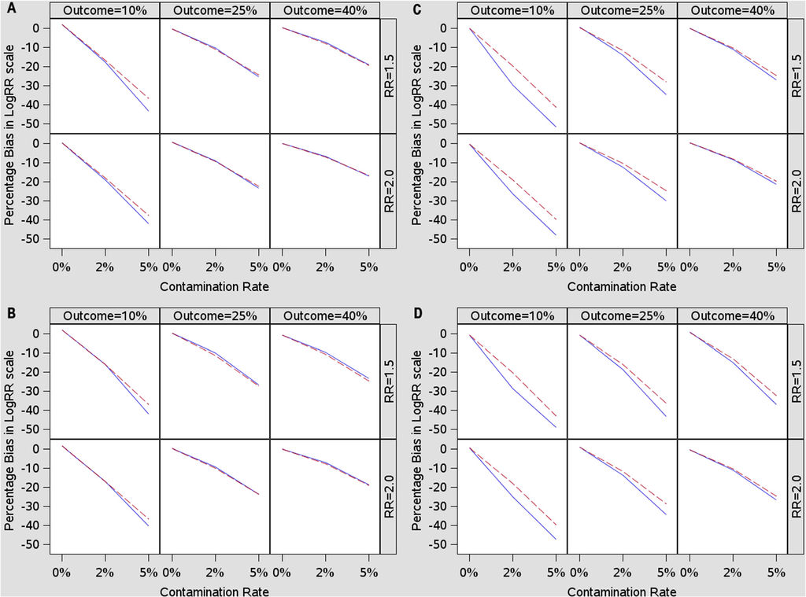

Our run, drawn on the published frame

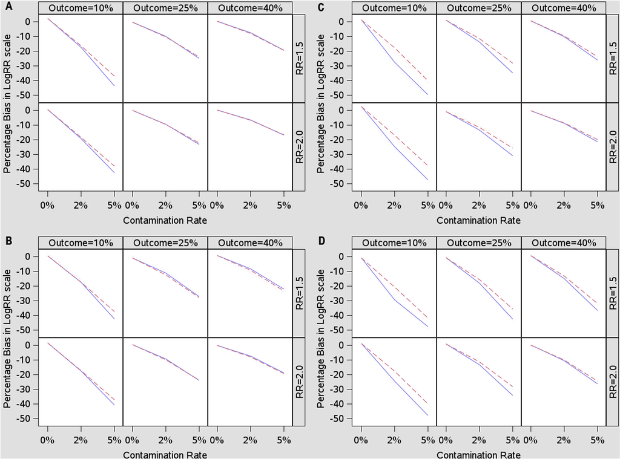

**Fig. 1A, relative bias, linear Z, moderate association (n = 1500)**

95.8% of the lines within 2 px (pass 95%, best control 73.6%), Agrees

**Fig. 1B, relative bias, linear Z, strong association (n = 1500)**

68.4% of the lines within 2 px (pass 95%, best control 56.8%); computed partly, set to agrees in review by hyunhwan-bcm, Agrees

**Fig. 1C, relative bias, non-linear Z, moderate association (n = 1500)**

41.3% of the lines within 2 px (pass 95%, best control 51.3%); computed inconclusive, set to agrees in review by hyunhwan-bcm, Agrees

**Fig. 1D, relative bias, non-linear Z, strong association (n = 1500)**

88.6% of the lines within 2 px (pass 95%, best control 83.8%); computed partly, set to agrees in review by hyunhwan-bcm, Agrees

Panel A passes the 2 px test; B and D fall short of it, and C cannot be told from a near miss. Two of our own runs score 0.674 to 0.741 against each other with the same code, while the paper's own Table 1 drawn this way scores at least 0.954: at 2 px the test cannot resolve Monte Carlo noise. Every value behind the four panels is within tolerance in Table 1.

## The tables

Every printed cell of Tables 1 to 3 (n = 1500) and of Tables A1 to A3 in Additional file 2 (n = 500), in the paper's layout. A cell agrees when ours is within half a printed unit plus three times the Monte Carlo error of the difference of two 1,000 replicate estimates.

## Table 1, relative bias (%) of the log RR, n = 1500 (18 rows x 8 cells)

Paper above, ours below; shaded where ours is outside the Monte Carlo tolerance. 144 of 144 cells within.

Agrees

| RR, P(Y = 1), contamination | Linear, moderate LB | Linear, moderate RP | Linear, strong LB | Linear, strong RP | Non-linear, moderate LB | Non-linear, moderate RP | Non-linear, strong LB | Non-linear, strong RP |
| --- | --- | --- | --- | --- | --- | --- | --- | --- |
| 1.5, 10%, 0% | 1.8 2.3 | 1.8 2.3 | 2.0 0.6 | 2.0 0.6 | 0.0 1.4 | 0.0 1.3 | -0.6 -0.8 | -0.8 -0.8 |
| 1.5, 10%, 2% | -17.8 -17.3 | -16.7 -16.3 | -16.0 -17.3 | -16.0 -17.3 | -30.0 -27.6 | -19.5 -17.7 | -28.5 -29.4 | -20.4 -20.6 |
| 1.5, 10%, 5% | -43.4 -43.7 | -36.7 -37.0 | -41.8 -42.4 | -36.9 -37.4 | -51.7 -49.6 | -41.3 -40.1 | -49.1 -47.5 | -43.0 -41.7 |
| 1.5, 25%, 0% | -0.4 -0.3 | -0.4 -0.3 | 0.4 -0.8 | 0.3 -0.8 | 0.5 1.1 | 0.5 1.1 | -0.8 -0.6 | -0.8 -0.6 |
| 1.5, 25%, 2% | -10.4 -9.9 | -10.9 -10.3 | -10.1 -11.1 | -11.4 -12.4 | -14.1 -13.8 | -11.8 -11.5 | -18.6 -18.0 | -16.2 -15.5 |
| 1.5, 25%, 5% | -25.3 -24.9 | -24.4 -23.9 | -26.6 -27.1 | -27.3 -27.8 | -34.6 -34.8 | -28.2 -28.2 | -43.4 -42.5 | -36.2 -35.6 |
| 1.5, 40%, 0% | 0.2 0.4 | 0.2 0.4 | -0.7 0.9 | -0.7 0.9 | -0.0 0.6 | -0.1 0.7 | 0.9 0.7 | 0.7 0.8 |
| 1.5, 40%, 2% | -7.5 -7.4 | -8.0 -7.9 | -9.8 -8.2 | -10.8 -9.2 | -11.0 -10.1 | -10.5 -9.6 | -14.9 -14.9 | -13.1 -13.1 |
| 1.5, 40%, 5% | -19.2 -19.4 | -19.4 -19.5 | -23.4 -22.0 | -24.6 -23.2 | -26.9 -26.1 | -24.7 -23.7 | -36.9 -36.6 | -32.2 -31.9 |
| 2.0, 10%, 0% | 0.4 0.6 | 0.4 0.6 | 1.5 1.5 | 1.5 1.5 | -0.2 2.7 | -0.2 2.7 | 0.6 1.2 | 0.7 1.2 |
| 2.0, 10%, 2% | -18.9 -19.2 | -18.1 -18.3 | -17.1 -17.5 | -16.8 -17.3 | -26.3 -24.8 | -19.0 -17.0 | -25.0 -24.5 | -18.0 -17.7 |
| 2.0, 10%, 5% | -42.0 -42.4 | -37.5 -38.0 | -40.2 -40.7 | -36.7 -37.2 | -47.9 -47.3 | -39.5 -37.7 | -47.4 -47.8 | -39.6 -40.0 |
| 2.0, 25%, 0% | 0.5 0.1 | 0.5 0.0 | 0.3 0.4 | 0.3 0.4 | 0.3 -0.8 | 0.3 -0.8 | 0.9 0.9 | 0.8 0.8 |
| 2.0, 25%, 2% | -9.0 -9.4 | -9.2 -9.6 | -9.2 -9.3 | -9.9 -10.0 | -12.3 -13.4 | -10.4 -11.6 | -13.7 -13.3 | -11.7 -11.3 |
| 2.0, 25%, 5% | -23.3 -23.2 | -22.2 -22.1 | -23.7 -23.9 | -23.6 -23.7 | -30.0 -30.9 | -24.7 -25.7 | -34.5 -34.2 | -28.5 -28.2 |
| 2.0, 40%, 0% | -0.1 0.3 | -0.1 0.3 | 0.1 -0.1 | 0.1 -0.1 | 0.3 -0.2 | 0.3 -0.2 | -0.3 0.2 | -0.3 0.1 |
| 2.0, 40%, 2% | -6.7 -6.5 | -7.0 -6.7 | -7.2 -7.4 | -7.8 -8.0 | -8.4 -8.7 | -8.0 -8.5 | -10.9 -10.5 | -10.2 -10.0 |
| 2.0, 40%, 5% | -16.9 -16.8 | -16.6 -16.5 | -18.5 -18.8 | -19.0 -19.3 | -21.2 -21.4 | -19.5 -19.9 | -26.6 -26.3 | -24.5 -24.4 |

## Table 2, empirical SE of the log RR, n = 1500 (18 rows x 8 cells)

Paper above, ours below; shaded where ours is outside the Monte Carlo tolerance. 144 of 144 cells within.

Agrees

| RR, P(Y = 1), contamination | Linear, moderate LB | Linear, moderate RP | Linear, strong LB | Linear, strong RP | Non-linear, moderate LB | Non-linear, moderate RP | Non-linear, strong LB | Non-linear, strong RP |
| --- | --- | --- | --- | --- | --- | --- | --- | --- |
| 1.5, 10%, 0% | 0.16 0.16 | 0.16 0.16 | 0.16 0.16 | 0.16 0.16 | 0.16 0.15 | 0.16 0.15 | 0.16 0.16 | 0.16 0.16 |
| 1.5, 10%, 2% | 0.14 0.14 | 0.14 0.14 | 0.14 0.14 | 0.14 0.14 | 0.15 0.15 | 0.14 0.14 | 0.14 0.15 | 0.14 0.14 |
| 1.5, 10%, 5% | 0.13 0.13 | 0.12 0.12 | 0.13 0.13 | 0.12 0.12 | 0.15 0.15 | 0.13 0.13 | 0.15 0.16 | 0.13 0.13 |
| 1.5, 25%, 0% | 0.10 0.09 | 0.10 0.09 | 0.09 0.09 | 0.09 0.09 | 0.09 0.09 | 0.09 0.09 | 0.09 0.09 | 0.09 0.09 |
| 1.5, 25%, 2% | 0.09 0.09 | 0.09 0.09 | 0.09 0.09 | 0.09 0.09 | 0.09 0.09 | 0.09 0.09 | 0.09 0.09 | 0.09 0.09 |
| 1.5, 25%, 5% | 0.08 0.09 | 0.08 0.09 | 0.08 0.08 | 0.08 0.08 | 0.09 0.09 | 0.09 0.08 | 0.08 0.09 | 0.08 0.09 |
| 1.5, 40%, 0% | 0.06 0.06 | 0.06 0.06 | 0.06 0.06 | 0.07 0.06 | 0.06 0.06 | 0.06 0.07 | 0.06 0.06 | 0.06 0.06 |
| 1.5, 40%, 2% | 0.06 0.06 | 0.06 0.06 | 0.06 0.06 | 0.06 0.06 | 0.06 0.06 | 0.06 0.06 | 0.06 0.06 | 0.06 0.06 |
| 1.5, 40%, 5% | 0.06 0.06 | 0.06 0.06 | 0.06 0.06 | 0.06 0.06 | 0.06 0.06 | 0.06 0.06 | 0.06 0.07 | 0.06 0.06 |
| 2.0, 10%, 0% | 0.17 0.17 | 0.17 0.17 | 0.16 0.17 | 0.16 0.17 | 0.16 0.17 | 0.16 0.17 | 0.17 0.17 | 0.17 0.17 |
| 2.0, 10%, 2% | 0.15 0.15 | 0.15 0.15 | 0.15 0.15 | 0.15 0.15 | 0.16 0.15 | 0.15 0.15 | 0.15 0.15 | 0.15 0.15 |
| 2.0, 10%, 5% | 0.14 0.14 | 0.13 0.13 | 0.13 0.13 | 0.13 0.13 | 0.15 0.16 | 0.13 0.13 | 0.16 0.16 | 0.13 0.13 |
| 2.0, 25%, 0% | 0.10 0.10 | 0.10 0.10 | 0.10 0.10 | 0.10 0.10 | 0.10 0.10 | 0.10 0.10 | 0.10 0.10 | 0.10 0.10 |
| 2.0, 25%, 2% | 0.09 0.09 | 0.09 0.09 | 0.10 0.10 | 0.10 0.10 | 0.09 0.10 | 0.09 0.09 | 0.09 0.10 | 0.09 0.09 |
| 2.0, 25%, 5% | 0.09 0.09 | 0.09 0.09 | 0.09 0.09 | 0.09 0.09 | 0.09 0.09 | 0.08 0.09 | 0.08 0.09 | 0.09 0.09 |
| 2.0, 40%, 0% | 0.07 0.07 | 0.07 0.07 | 0.07 0.07 | 0.07 0.07 | 0.07 0.07 | 0.07 0.07 | 0.07 0.07 | 0.07 0.07 |
| 2.0, 40%, 2% | 0.07 0.07 | 0.07 0.07 | 0.07 0.07 | 0.07 0.07 | 0.07 0.07 | 0.07 0.07 | 0.07 0.07 | 0.07 0.07 |
| 2.0, 40%, 5% | 0.07 0.07 | 0.07 0.07 | 0.07 0.07 | 0.07 0.07 | 0.07 0.07 | 0.07 0.07 | 0.07 0.07 | 0.07 0.07 |

## Table 3, MSE of the log RR, n = 1500 (18 rows x 8 cells)

Paper above, ours below; shaded where ours is outside the Monte Carlo tolerance. 143 of 143 cells within. The italic cell is a misprint of the paper and is left out.

Agrees

| RR, P(Y = 1), contamination | Linear, moderate LB | Linear, moderate RP | Linear, strong LB | Linear, strong RP | Non-linear, moderate LB | Non-linear, moderate RP | Non-linear, strong LB | Non-linear, strong RP |
| --- | --- | --- | --- | --- | --- | --- | --- | --- |
| 1.5, 10%, 0% | 0.025 0.025 | 0.025 0.025 | 0.027 0.025 | 0.027 0.025 | 0.025 0.024 | 0.025 0.024 | 0.024 0.026 | 0.024 0.027 |
| 1.5, 10%, 2% | 0.026 0.025 | 0.025 0.024 | 0.025 0.025 | 0.024 0.025 | 0.036 0.034 | 0.026 0.025 | 0.033 0.036 | 0.026 0.028 |
| 1.5, 10%, 5% | 0.049 0.049 | 0.038 0.038 | 0.045 0.046 | 0.038 0.038 | 0.066 0.064 | 0.044 0.043 | 0.063 0.062 | 0.046 0.045 |
| 1.5, 25%, 0% | 0.008 0.009 | 0.008 0.009 | 0.008 0.008 | 0.008 0.008 | 0.009 0.008 | 0.009 0.008 | 0.008 0.008 | 0.008 0.008 |
| 1.5, 25%, 2% | 0.010 0.010 | 0.010 0.010 | 0.009 0.010 | 0.010 0.010 | 0.011 0.011 | 0.010 0.010 | 0.013 0.013 | 0.012 0.012 |
| 1.5, 25%, 5% | 0.018 0.018 | 0.017 0.017 | 0.019 0.019 | 0.019 0.020 | 0.027 0.028 | 0.020 0.020 | 0.038 0.037 | 0.028 0.028 |
| 1.5, 40%, 0% | 0.004 0.004 | 0.004 0.004 | 0.004 0.004 | 0.004 0.004 | 0.004 0.004 | 0.004 0.004 | 0.004 0.004 | 0.004 0.004 |
| 1.5, 40%, 2% | 0.005 0.005 | 0.005 0.005 | 0.006 0.005 | 0.006 0.005 | 0.006 0.006 | 0.006 0.006 | 0.008 0.008 | 0.007 0.007 |
| 1.5, 40%, 5% | 0.010 0.010 | 0.010 0.010 | 0.013 0.012 | 0.014 0.013 | 0.016 0.015 | 0.014 0.013 | 0.027 0.026 | 0.021 0.021 |
| 2.0, 10%, 0% | 0.028 0.028 | 0.028 0.028 | 0.027 0.029 | 0.027 0.029 | 0.027 0.028 | 0.027 0.028 | 0.029 0.030 | 0.029 0.030 |
| 2.0, 10%, 2% | 0.040 0.040 | 0.038 0.038 | 0.035 0.036 | 0.035 0.036 | 0.057 0.053 | 0.039 0.035 | 0.053 0.052 | 0.038 0.038 |
| 2.0, 10%, 5% | 0.105 0.106 | 0.085 0.086 | 0.096 0.097 | 0.081 0.082 | 0.134 0.132 | 0.091 0.085 | 0.135 0.135 | 0.093 0.095 |
| 2.0, 25%, 0% | 0.009 0.010 | 0.009 0.010 | 0.010 0.010 | 0.010 0.010 | 0.009 0.010 | 0.009 0.010 | 0.009 0.010 | 0.010 0.010 |
| 2.0, 25%, 2% | 0.012 0.013 | 0.013 0.013 | 0.014 0.013 | 0.014 0.014 | 0.016 0.018 | 0.014 0.015 | 0.018 0.018 | 0.016 0.015 |
| 2.0, 25%, 5% | 0.034 0.034 | 0.031 0.031 | 0.013 0.036 | 0.035 0.035 | 0.051 0.054 | 0.036 0.040 | 0.065 0.064 | 0.047 0.046 |
| 2.0, 40%, 0% | 0.005 0.005 | 0.005 0.005 | 0.005 0.005 | 0.005 0.005 | 0.005 0.005 | 0.005 0.005 | 0.005 0.004 | 0.005 0.005 |
| 2.0, 40%, 2% | 0.007 0.007 | 0.007 0.007 | 0.007 0.007 | 0.008 0.008 | 0.008 0.009 | 0.008 0.008 | 0.011 0.010 | 0.010 0.009 |
| 2.0, 40%, 5% | 0.018 0.018 | 0.018 0.018 | 0.021 0.021 | 0.022 0.022 | 0.026 0.027 | 0.023 0.024 | 0.039 0.038 | 0.034 0.033 |

## Additional file 2, Table A1, relative bias (%), n = 500

Paper above, ours below; shaded where ours is outside the Monte Carlo tolerance. 144 of 144 cells within.

Agrees

| RR, P(Y = 1), contamination | Linear, moderate LB | Linear, moderate RP | Linear, strong LB | Linear, strong RP | Non-linear, moderate LB | Non-linear, moderate RP | Non-linear, strong LB | Non-linear, strong RP |
| --- | --- | --- | --- | --- | --- | --- | --- | --- |
| 1.5, 10%, 0% | 3.1 -1.0 | 3.2 -1.0 | 4.4 -0.5 | 4.4 -0.5 | 0.4 4.1 | 0.4 4.2 | 0.1 3.1 | -0.1 3.2 |
| 1.5, 10%, 2% | -17.3 -20.1 | -15.5 -18.5 | -14.2 -19.9 | -13.8 -19.2 | -28.1 -23.1 | -17.8 -13.7 | -24.7 -21.2 | -17.2 -13.8 |
| 1.5, 10%, 5% | -43.0 -46.3 | -35.3 -38.7 | -40.6 -43.7 | -35.1 -37.8 | -51.8 -48.4 | -39.7 -37.4 | -46.8 -44.2 | -39.0 -37.0 |
| 1.5, 25%, 0% | 0.0 1.1 | -0.4 1.2 | 1.3 -0.1 | 1.2 -0.1 | 3.4 2.0 | 3.4 2.0 | -0.5 1.7 | -0.6 1.6 |
| 1.5, 25%, 2% | -9.9 -9.1 | -10.3 -9.4 | -9.5 -10.4 | -10.7 -11.6 | -11.3 -12.5 | -8.8 -9.9 | -18.1 -15.8 | -15.4 -13.0 |
| 1.5, 25%, 5% | -25.4 -25.0 | -24.2 -23.7 | -27.0 -26.8 | -27.3 -27.1 | -32.2 -33.1 | -25.3 -26.2 | -43.6 -40.3 | -35.9 -32.8 |
| 1.5, 40%, 0% | 0.2 0.3 | 0.1 0.3 | 0.2 0.4 | 0.2 0.3 | 1.0 1.2 | 0.8 1.0 | 1.4 -0.6 | 1.2 -0.3 |
| 1.5, 40%, 2% | -7.9 -7.1 | -8.2 -7.5 | -8.8 -8.7 | -10.0 -9.7 | -9.6 -9.9 | -9.1 -9.1 | -14.2 -16.1 | -12.2 -13.5 |
| 1.5, 40%, 5% | -19.7 -19.0 | -19.6 -19.0 | -22.4 -22.7 | -23.5 -23.8 | -26.1 -26.0 | -23.7 -23.3 | -36.0 -37.3 | -31.2 -32.1 |
| 2.0, 10%, 0% | 2.1 1.4 | 2.1 1.4 | 4.0 2.4 | 4.0 2.4 | 2.4 1.4 | 2.4 1.4 | 2.6 -0.9 | 2.7 -0.9 |
| 2.0, 10%, 2% | -17.7 -18.7 | -16.6 -17.5 | -15.6 -16.1 | -15.0 -15.6 | -21.5 -23.3 | -14.4 -16.0 | -22.0 -26.3 | -15.4 -19.6 |
| 2.0, 10%, 5% | -40.4 -42.8 | -35.6 -37.5 | -39.7 -40.8 | -35.3 -36.5 | -43.8 -46.8 | -35.5 -37.3 | -45.5 -50.4 | -37.0 -41.4 |
| 2.0, 25%, 0% | 0.1 1.7 | 0.1 1.7 | 0.3 1.2 | 0.2 1.2 | 0.3 0.3 | 0.3 0.2 | 2.0 0.8 | 1.8 0.8 |
| 2.0, 25%, 2% | -9.7 -7.9 | -9.8 -7.9 | -9.2 -8.7 | -9.7 -9.2 | -12.2 -11.9 | -10.1 -9.9 | -12.3 -13.4 | -10.0 -11.2 |
| 2.0, 25%, 5% | -24.0 -22.1 | -22.6 -20.8 | -23.8 -23.7 | -23.4 -23.3 | -29.4 -29.1 | -24.0 -23.8 | -33.1 -34.0 | -26.9 -27.9 |
| 2.0, 40%, 0% | -0.9 0.6 | -0.9 0.6 | 0.6 0.4 | 0.5 0.4 | 0.2 0.2 | 0.2 0.1 | -0.3 0.8 | -0.1 0.9 |
| 2.0, 40%, 2% | -7.7 -6.4 | -7.9 -6.6 | -6.7 -6.9 | -7.3 -7.5 | -8.3 -8.4 | -7.7 -7.9 | -11.0 -10.0 | -10.0 -9.1 |
| 2.0, 40%, 5% | -17.8 -16.5 | -17.5 -16.2 | -18.2 -18.6 | -18.6 -18.9 | -21.0 -21.2 | -19.1 -19.4 | -26.7 -25.8 | -24.1 -23.4 |

## Additional file 2, Table A2, empirical SE, n = 500

Paper above, ours below; shaded where ours is outside the Monte Carlo tolerance. 144 of 144 cells within.

Agrees

| RR, P(Y = 1), contamination | Linear, moderate LB | Linear, moderate RP | Linear, strong LB | Linear, strong RP | Non-linear, moderate LB | Non-linear, moderate RP | Non-linear, strong LB | Non-linear, strong RP |
| --- | --- | --- | --- | --- | --- | --- | --- | --- |
| 1.5, 10%, 0% | 0.27 0.29 | 0.27 0.29 | 0.29 0.28 | 0.29 0.28 | 0.29 0.29 | 0.29 0.29 | 0.28 0.29 | 0.28 0.29 |
| 1.5, 10%, 2% | 0.24 0.26 | 0.24 0.26 | 0.25 0.25 | 0.25 0.25 | 0.26 0.27 | 0.26 0.27 | 0.25 0.26 | 0.25 0.26 |
| 1.5, 10%, 5% | 0.23 0.24 | 0.21 0.22 | 0.23 0.23 | 0.22 0.22 | 0.26 0.26 | 0.23 0.23 | 0.24 0.26 | 0.22 0.23 |
| 1.5, 25%, 0% | 0.17 0.16 | 0.17 0.16 | 0.16 0.16 | 0.16 0.16 | 0.17 0.16 | 0.17 0.16 | 0.16 0.16 | 0.16 0.16 |
| 1.5, 25%, 2% | 0.17 0.16 | 0.17 0.16 | 0.16 0.15 | 0.16 0.15 | 0.16 0.16 | 0.16 0.16 | 0.16 0.16 | 0.16 0.16 |
| 1.5, 25%, 5% | 0.16 0.15 | 0.16 0.15 | 0.15 0.14 | 0.15 0.14 | 0.16 0.16 | 0.15 0.15 | 0.15 0.15 | 0.15 0.15 |
| 1.5, 40%, 0% | 0.11 0.11 | 0.11 0.11 | 0.11 0.12 | 0.11 0.12 | 0.11 0.12 | 0.11 0.12 | 0.11 0.11 | 0.11 0.11 |
| 1.5, 40%, 2% | 0.11 0.11 | 0.11 0.11 | 0.11 0.12 | 0.11 0.12 | 0.11 0.12 | 0.11 0.12 | 0.11 0.11 | 0.11 0.11 |
| 1.5, 40%, 5% | 0.11 0.11 | 0.11 0.11 | 0.11 0.11 | 0.11 0.11 | 0.11 0.12 | 0.10 0.11 | 0.11 0.12 | 0.11 0.11 |
| 2.0, 10%, 0% | 0.30 0.30 | 0.30 0.30 | 0.30 0.30 | 0.30 0.30 | 0.30 0.31 | 0.30 0.31 | 0.30 0.29 | 0.30 0.29 |
| 2.0, 10%, 2% | 0.27 0.26 | 0.26 0.26 | 0.26 0.26 | 0.25 0.26 | 0.27 0.29 | 0.26 0.28 | 0.26 0.27 | 0.26 0.26 |
| 2.0, 10%, 5% | 0.24 0.24 | 0.23 0.22 | 0.24 0.24 | 0.22 0.22 | 0.25 0.27 | 0.23 0.24 | 0.25 0.25 | 0.23 0.23 |
| 2.0, 25%, 0% | 0.17 0.17 | 0.17 0.17 | 0.17 0.17 | 0.17 0.17 | 0.17 0.16 | 0.17 0.16 | 0.17 0.16 | 0.18 0.16 |
| 2.0, 25%, 2% | 0.16 0.16 | 0.16 0.16 | 0.17 0.16 | 0.17 0.16 | 0.17 0.16 | 0.16 0.15 | 0.17 0.16 | 0.17 0.16 |
| 2.0, 25%, 5% | 0.16 0.15 | 0.15 0.15 | 0.16 0.15 | 0.16 0.15 | 0.16 0.15 | 0.15 0.15 | 0.16 0.15 | 0.16 0.15 |
| 2.0, 40%, 0% | 0.12 0.12 | 0.12 0.12 | 0.12 0.12 | 0.12 0.12 | 0.12 0.12 | 0.12 0.12 | 0.12 0.12 | 0.12 0.12 |
| 2.0, 40%, 2% | 0.12 0.12 | 0.12 0.12 | 0.11 0.12 | 0.12 0.12 | 0.12 0.12 | 0.12 0.12 | 0.12 0.12 | 0.12 0.12 |
| 2.0, 40%, 5% | 0.11 0.12 | 0.11 0.11 | 0.11 0.11 | 0.11 0.12 | 0.12 0.12 | 0.11 0.12 | 0.12 0.13 | 0.12 0.12 |

## Additional file 2, Table A3, MSE, n = 500

Paper above, ours below; shaded where ours is outside the Monte Carlo tolerance. 144 of 144 cells within.

Agrees

| RR, P(Y = 1), contamination | Linear, moderate LB | Linear, moderate RP | Linear, strong LB | Linear, strong RP | Non-linear, moderate LB | Non-linear, moderate RP | Non-linear, strong LB | Non-linear, strong RP |
| --- | --- | --- | --- | --- | --- | --- | --- | --- |
| 1.5, 10%, 0% | 0.073 0.086 | 0.073 0.087 | 0.082 0.081 | 0.082 0.081 | 0.083 0.086 | 0.083 0.086 | 0.077 0.084 | 0.077 0.084 |
| 1.5, 10%, 2% | 0.063 0.075 | 0.061 0.073 | 0.066 0.071 | 0.066 0.070 | 0.082 0.082 | 0.072 0.074 | 0.072 0.077 | 0.067 0.072 |
| 1.5, 10%, 5% | 0.083 0.092 | 0.065 0.075 | 0.079 0.083 | 0.068 0.071 | 0.111 0.106 | 0.079 0.078 | 0.094 0.097 | 0.074 0.076 |
| 1.5, 25%, 0% | 0.028 0.026 | 0.028 0.026 | 0.027 0.025 | 0.027 0.025 | 0.028 0.027 | 0.028 0.027 | 0.026 0.027 | 0.026 0.027 |
| 1.5, 25%, 2% | 0.029 0.026 | 0.029 0.026 | 0.026 0.024 | 0.027 0.025 | 0.028 0.028 | 0.027 0.027 | 0.030 0.029 | 0.028 0.028 |
| 1.5, 25%, 5% | 0.035 0.034 | 0.034 0.032 | 0.034 0.032 | 0.034 0.032 | 0.042 0.042 | 0.034 0.035 | 0.053 0.050 | 0.043 0.041 |
| 1.5, 40%, 0% | 0.013 0.013 | 0.013 0.013 | 0.012 0.013 | 0.012 0.014 | 0.012 0.014 | 0.012 0.014 | 0.013 0.013 | 0.013 0.013 |
| 1.5, 40%, 2% | 0.013 0.014 | 0.013 0.014 | 0.013 0.015 | 0.014 0.015 | 0.013 0.016 | 0.013 0.015 | 0.016 0.017 | 0.015 0.016 |
| 1.5, 40%, 5% | 0.018 0.018 | 0.018 0.018 | 0.020 0.021 | 0.021 0.022 | 0.022 0.025 | 0.020 0.022 | 0.034 0.036 | 0.028 0.030 |
| 2.0, 10%, 0% | 0.087 0.088 | 0.087 0.088 | 0.089 0.089 | 0.089 0.089 | 0.092 0.097 | 0.092 0.097 | 0.091 0.087 | 0.091 0.087 |
| 2.0, 10%, 2% | 0.088 0.086 | 0.083 0.081 | 0.077 0.082 | 0.075 0.080 | 0.098 0.109 | 0.082 0.091 | 0.092 0.104 | 0.079 0.085 |
| 2.0, 10%, 5% | 0.138 0.144 | 0.113 0.117 | 0.131 0.136 | 0.110 0.113 | 0.156 0.179 | 0.113 0.126 | 0.164 0.187 | 0.119 0.134 |
| 2.0, 25%, 0% | 0.029 0.029 | 0.029 0.029 | 0.029 0.029 | 0.030 0.029 | 0.029 0.026 | 0.029 0.026 | 0.031 0.026 | 0.031 0.026 |
| 2.0, 25%, 2% | 0.031 0.028 | 0.031 0.028 | 0.032 0.030 | 0.032 0.030 | 0.034 0.032 | 0.031 0.029 | 0.036 0.034 | 0.034 0.030 |
| 2.0, 25%, 5% | 0.053 0.046 | 0.049 0.043 | 0.052 0.051 | 0.051 0.049 | 0.066 0.064 | 0.051 0.048 | 0.079 0.078 | 0.061 0.059 |
| 2.0, 40%, 0% | 0.015 0.015 | 0.015 0.015 | 0.014 0.014 | 0.014 0.014 | 0.015 0.014 | 0.015 0.014 | 0.014 0.015 | 0.014 0.016 |
| 2.0, 40%, 2% | 0.017 0.017 | 0.017 0.017 | 0.015 0.016 | 0.016 0.017 | 0.017 0.017 | 0.017 0.017 | 0.020 0.020 | 0.019 0.019 |
| 2.0, 40%, 5% | 0.028 0.026 | 0.027 0.026 | 0.028 0.030 | 0.029 0.030 | 0.035 0.036 | 0.031 0.031 | 0.048 0.048 | 0.041 0.041 |

## Every result

Each table, figure panel and statement of the paper. check_results.py computes every verdict from the numbers.

Result

Verdict

Measure

Why

Additional file 1, the 24 scenarios: exposure 50% and outcome 10, 25 or 40%

Exact

48 of 48 values within tolerance

Table 1, relative bias (%) of the log RR, n = 1500 (18 rows x 8 cells)

Agrees

144 of 144 values within tolerance

Fig. 1A, relative bias, linear Z, moderate association (n = 1500)

Agrees

95.8% of the lines within 2 px (pass 95%, best control 73.6%)

Ours scores 0.958 against a pass mark of 0.95; the best wrong input scores 0.175 and the best near miss 0.736. At 2 px a pixel score cannot resolve Monte Carlo noise: one point of relative bias is 4.62 px, and the Monte Carlo SE of a 1,000-replicate relative bias is 0.3 to 1.3 points. Two runs of our own simulation with different seeds score only 0.741 against each other in this panel, while the paper's own Table 1 drawn with the same code scores 0.983, so the drawing and the frame are right. The values behind the panel are Table 1: its 36 values for this panel are each within tolerance and sit at an RMS z of 0.43 from the paper's, where our two runs sit at 0.84 from each other.

Fig. 1B, relative bias, linear Z, strong association (n = 1500)

Agrees

68.4% of the lines within 2 px (pass 95%, best control 56.8%); computed partly, set to agrees in review by hyunhwan-bcm

Ours scores 0.684 against a pass mark of 0.95; the best wrong input scores 0.156 and the best near miss 0.568. At 2 px a pixel score cannot resolve Monte Carlo noise: one point of relative bias is 4.62 px, and the Monte Carlo SE of a 1,000-replicate relative bias is 0.3 to 1.3 points. Two runs of our own simulation with different seeds score only 0.736 against each other in this panel, while the paper's own Table 1 drawn with the same code scores 0.970, so the drawing and the frame are right. The values behind the panel are Table 1: its 36 values for this panel are each within tolerance and sit at an RMS z of 1.05 from the paper's, where our two runs sit at 1.22 from each other.

Fig. 1C, relative bias, non-linear Z, moderate association (n = 1500)

Agrees

41.3% of the lines within 2 px (pass 95%, best control 51.3%); computed inconclusive, set to agrees in review by hyunhwan-bcm

Ours scores 0.413 against a pass mark of 0.95; the best wrong input scores 0.148 and the best near miss 0.513. At 2 px a pixel score cannot resolve Monte Carlo noise: one point of relative bias is 4.62 px, and the Monte Carlo SE of a 1,000-replicate relative bias is 0.3 to 1.3 points. Two runs of our own simulation with different seeds score only 0.674 against each other in this panel, while the paper's own Table 1 drawn with the same code scores 0.954, so the drawing and the frame are right. The values behind the panel are Table 1: its 36 values for this panel are each within tolerance and sit at an RMS z of 1.36 from the paper's, where our two runs sit at 1.12 from each other.

Fig. 1D, relative bias, non-linear Z, strong association (n = 1500)

Agrees

88.6% of the lines within 2 px (pass 95%, best control 83.8%); computed partly, set to agrees in review by hyunhwan-bcm

Ours scores 0.886 against a pass mark of 0.95; the best wrong input scores 0.092 and the best near miss 0.838. At 2 px a pixel score cannot resolve Monte Carlo noise: one point of relative bias is 4.62 px, and the Monte Carlo SE of a 1,000-replicate relative bias is 0.3 to 1.3 points. Two runs of our own simulation with different seeds score only 0.714 against each other in this panel, while the paper's own Table 1 drawn with the same code scores 0.956, so the drawing and the frame are right. The values behind the panel are Table 1: its 36 values for this panel are each within tolerance and sit at an RMS z of 0.55 from the paper's, where our two runs sit at 0.70 from each other.

Fig. 1 draws Table 1 (the published vertices read back)

Agrees

121 of the 123 vertices of Fig. 1 that can be read (of 144) lie within 1 point of Table 1 as printed; largest difference 1.09 points

Table 2, empirical SE of the log RR, n = 1500 (18 rows x 8 cells)

Agrees

144 of 144 values within tolerance

Table 3, MSE of the log RR, n = 1500 (18 rows x 8 cells)

Agrees

143 of 143 values within tolerance (1 slip of the paper left out)

Additional file 2, Table A1, relative bias (%), n = 500

Agrees

144 of 144 values within tolerance

Additional file 2, Table A2, empirical SE, n = 500

Agrees

144 of 144 values within tolerance

Additional file 2, Table A3, MSE, n = 500

Agrees

144 of 144 values within tolerance

Results: with contamination every relative bias is negative

Agrees

1 of 1 values within tolerance

- Table 1: every relative bias of the contaminated rows is negative (96 values): paper yes, ours **yes**

Results: lower outcome rates go with larger biases

Agrees

2 of 2 values within tolerance

- Table 1: |bias| at outcome 10% exceeds |bias| at 25%, every contaminated cell and model (32 pairs): paper yes, ours **yes**
- Table 1: |bias| at outcome 25% exceeds |bias| at 40%, every contaminated cell and model (32 pairs): paper yes, ours **yes**

Results: linear Z, log-binomial 3.5% to 6.7% more biased at outcome 10% and 5% contamination

Agrees

3 of 3 values within tolerance

- Linear Z: the largest LB - RP gaps in |bias| are at 5% contamination and 10% outcome: paper yes, ours **yes**
- Linear Z, 5% contamination, 10% outcome: smallest gap (points): paper 3.5, ours **3.6**
- Linear Z, 5% contamination, 10% outcome: largest gap (points): paper 6.7, ours **6.7**

Results: non-linear Z, robust Poisson less biased from 2% contamination on

Agrees

3 of 3 values within tolerance

- Non-linear Z: RP less biased than LB in every contaminated cell (24): paper yes, ours **yes**
- Non-linear Z: RP less biased than LB in every 2% cell (12): paper yes, ours **yes**
- Non-linear Z: the gap is larger at outcome 10% than at 40% (8 pairs): paper yes, ours **yes**

Results: without contamination the two SEs are identical at the 2nd decimal

Agrees

1 of 1 values within tolerance (1 slip of the paper left out)

- Table 2, 0% rows: LB and RP SEs equal at the 2nd decimal in all 24 pairs: paper yes, ours **no** (the paper's own table breaks it; left out)
- Table 2, 0% rows: LB and RP SEs differ by less than 0.005 before rounding (24 pairs): paper yes, ours **yes**

Results: with contamination, comparable SEs at outcome 25% and 40%, log-binomial higher at 10%

Agrees

2 of 2 values within tolerance

- Table 2, contaminated rows at outcome 10%: LB SE above RP SE in some cells: paper yes, ours **yes**
- Table 2, contaminated rows at outcome 25% and 40%: LB and RP SEs within 0.01 in every cell: paper yes, ours **yes**

Results: the MSEs follow the biases

Agrees

2 of 2 values within tolerance

- Table 3, linear Z: LB MSE exceeds RP MSE by more than 0.005 only at outcome 10% and 5% contamination: paper yes, ours **yes**
- Table 3, non-linear Z: LB MSE at least RP MSE in every 2% cell (12), as printed: paper yes, ours **yes**

Results: the same pattern at n = 500, with larger SEs

Agrees

2 of 2 values within tolerance

- Table A2 SE above Table 2 SE in every cell (144): paper yes, ours **yes**
- Table A1, non-linear Z: RP less biased than LB in every contaminated cell (24): paper yes, ours **yes**

Discussion: no difference between the models without outliers

Agrees

1 of 1 values within tolerance

- 0% rows of Tables 1 and A1: LB and RP relative biases within 0.5 points in all 48 pairs: paper yes, ours **yes**

Discussion: COPY converged in all fits of 48 of 48 linear and 30 of 48 non-linear scenarios

Partly agrees

1 of 2 values within tolerance

- Linear Z: scenarios with every log-binomial fit converged (of 48): paper 48, ours **48**
- Non-linear Z: scenarios with every log-binomial fit converged (of 48): paper 30, ours **48**

Every log-binomial fit of ours converges, plain or COPY, so ours counts 48 of 48 non-linear scenarios against the paper's 30. The paper's failures are failures of SAS GENMOD's optimizer on the COPY data, which we cannot run. The boundary that COPY handles is common in our non-linear runs: COPY is needed in some fit of 47 of 48 non-linear scenarios (up to 863 of 1,000 fits, median 172) and of 5 of 48 linear ones (at most 2 fits), which agrees with the paper's split between the forms but cannot say which 18 failed.

Main claim: comparable models with a linear Z; robust Poisson less biased with a quadratic Z from 2% contamination on

Agrees

2 of 2 values within tolerance

- Linear Z: LB and RP |bias| within 2 points in every contaminated cell except outcome 10% at 5%: paper yes, ours **yes**
- Non-linear Z: RP less biased than LB in every contaminated cell, from 2% on (24): paper yes, ours **yes**

Discussion: results cited from Petersen and Deddens (three decimals with 10,000 copies; 70% to 100% convergence)

Not attempted

Results of another paper, quoted in the Discussion; this paper does not compute them.

Each statement of the text recomputed from the paper's own tables

Agrees

18 of 19 statements follow from the paper's own tables. Not: text.se_uncontaminated: Table 2, 0% rows: LB and RP SEs equal at the 2nd decimal in all 24 pairs (yes against no).

robustrr's fits against statsmodels and an independent maximizer

Agrees

60 contaminated data sets (8 COPY fits): robust Poisson coefficients equal statsmodels' to 1.2e-12 and the sandwich SE its HC0 SE to a relative 3.1e-12; log-binomial coefficients equal an independent maximizer's to 1.0e-06, with a likelihood at least as high (to 1.1e-13) and a score of at most 4.0e-06

The authors' SAS 9.2 program and COPY macro

Not attempted

The simulation program was never released, and the revised COPY macro of Petersen and Deddens is not online (its NIOSH page answers 403). Both are SAS, which no free runtime runs. The method is implemented from the paper's text and checked against its printed tables.

Python package robustrr and its tutorial

Agrees

robustrr 0.1.0: wheel installed in a fresh environment and imported from it; tests 8 passed; tutorial 6 cells compared, 0 skipped (nondeterministic); TUTORIAL.md in sync

The main claim holds. Every statement about bias, SE and MSE holds on our run but one, which the paper's own Table 2 breaks as well: without contamination the two SEs differ by less than 0.0009, yet they can round to different second decimals. The one table cell that misses is a misprint in Table 3, and the convergence count of the Discussion belongs to SAS, which we cannot run.

## What came back

**The simulation**

All 24 scenarios at n = 1500 and n = 500, rebuilt as the Python package robustrr and run again with 1,000 replicates each.

**The tables**

863 of 864 printed cells within Monte Carlo error. The one miss is Table 3 printing 0.013 where its own bias and SE give 0.0351; ours is 0.0357.

**The contamination rule**

Records past fixed quantiles of p_y are flipped, so how many are flipped varies from data set to data set. Flipping a fixed number in every data set makes the SEs too small at outcome 10%.

**Fig. 1**

Drawn on the published picture. Panel A passes the 2 px test. B and D fall short of it and C cannot be told from a near miss, while every value behind them is within Monte Carlo tolerance: two of our own runs pass the same test no better.

**The claims**

Robust Poisson is less biased than log-binomial in every contaminated cell with a quadratic confounder, and the two are within 2 points with a linear one except at outcome 10% and 5% contamination.

## What stayed buried

- The authors' SAS 9.2 program and the revised COPY macro.
- Which 18 non-linear scenarios SAS failed to fit. Every fit of ours converges.

The main claim holds. Every statement about bias, SE and MSE holds on our run but one, which the paper's own Table 2 breaks as well: without contamination the two SEs differ by less than 0.0009, yet they can round to different second decimals. The one table cell that misses is a misprint in Table 3, and the convergence count of the Discussion belongs to SAS, which we cannot run.

## What we matched

Each line is a count against the paper's printed values; the last checks the paper's figure against its own table.

**Table 1, relative bias**

144 of 144 cells

**Table 2, SE**

144 of 144 cells

**Table 3, MSE**

143 of 144 cells; the miss is a misprint

**Tables A1 to A3, n = 500**

144, 144 and 144 of 144 cells

**Linear Z gaps at outcome 10% and 5%**

paper 6.7, 4.9, 4.5, 3.5; ours 6.66, 5.00, 4.47, 3.58

**Fig. 1 against the paper's own Table 1**

121 of 123 readable vertices within 1 point

## The session

The reproduction was done by an AI agent, Claude Code, in one session. Every prompt, reply and tool call of it is published.

**Wall clock**

86 min

first message to last, waits included

**Human prompts**

6

messages typed by a person

**Tool calls**

224

32 of them in subagents

**Tokens**

66.3 M

every request, subagents included

Read the session [The raw files](https://github.com/jeonglab-bcm/fossil/tree/main/PMC4079617/session)